# 2024 NH3-loss Statistical Models

## Model A_Irrigation

Irrigation was modeled as a binomial variable due to heavy zero-inflation in the data.

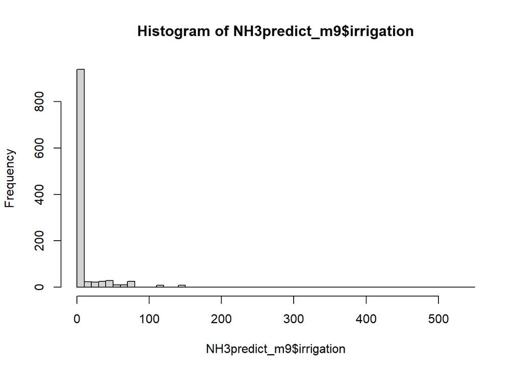

The number of observations in total in each category can be seen below:

```
##   irrigation_cat   N
## 1              0 900
## 2              1 202
```

```r
# Model
m9_lm <- lm(sqrt(NH3loss+4) ~ irrigation_cat + offset(M1_fit),
            weights=Weight,
            data=NH3predict_m9)
```

The check for normality and heteroscedasticity of errors can be seen below:

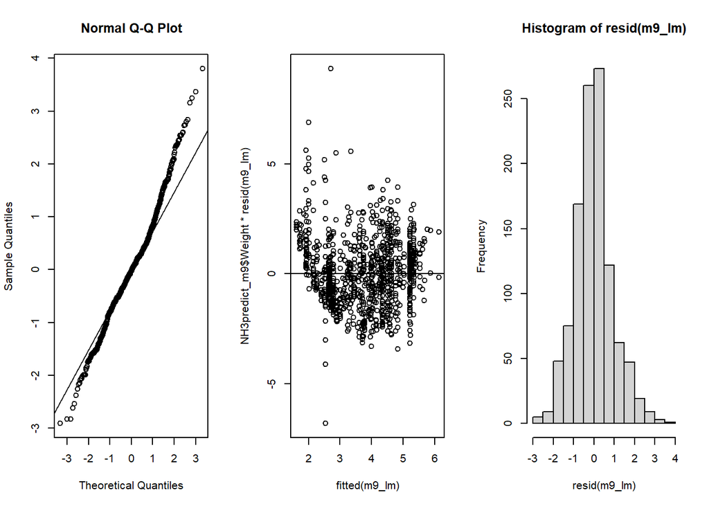

There was no effect of irrigation on NH3-loss (F(1, 1100) =0.36, p = 0.549).

```
##
## Call:
## lm(formula = sqrt(NH3loss + 4) ~ irrigation_cat + offset(M1_fit),
##     data = NH3predict_m9, weights = Weight)
##
## Weighted Residuals:
##     Min      1Q  Median      3Q     Max
## -4.1556 -0.7598 -0.0326  0.6592  5.9584
##
## Coefficients:
##                  Estimate Std. Error t value Pr(>|t|)
## (Intercept)      0.004534   0.027400   0.165    0.869
## irrigation_cat1 -0.040327   0.067343  -0.599    0.549
##
## Residual standard error: 1.156 on 1100 degrees of freedom
## Multiple R-squared:  0.0003259,  Adjusted R-squared:  -0.0005829
## F-statistic: 0.3586 on 1 and 1100 DF,  p-value: 0.5494
```

Adjusted R2-value of the model was -5.8^{-4}, and multiple R2 was 3.3^{-4}. The negative adjusted R2-value indicates that the amount of variation accounted for by irrigation is negligible. In practice, it explain no variation in the data.

The marginal means for NH3 loss in no-irrigation and irrigation categories can be seen below.

```
##   irrigation_cat   emmean         SE   df lower.CL upper.CL
## 1              0 3.712972 0.02740036 1100 3.659209 3.766735
## 2              1 3.672645 0.06151617 1100 3.551943 3.793347
```

```
## `height` was translated to `width`.
```

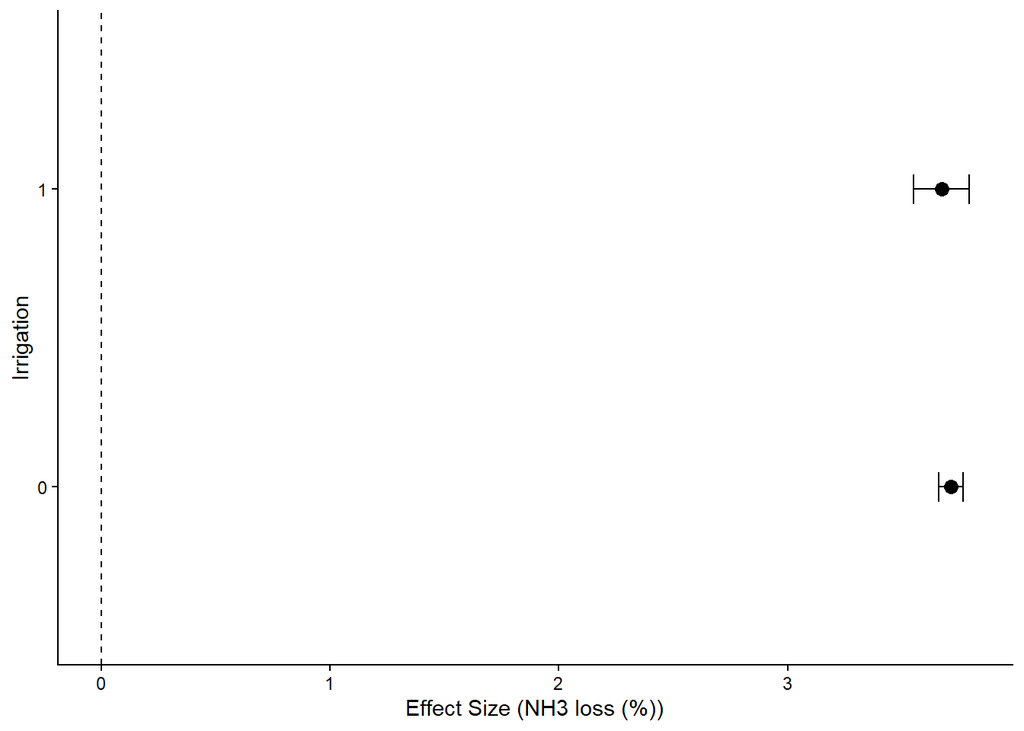

## Model A_Water input

Daily water input (mm) consists of irrigation and rainfall.

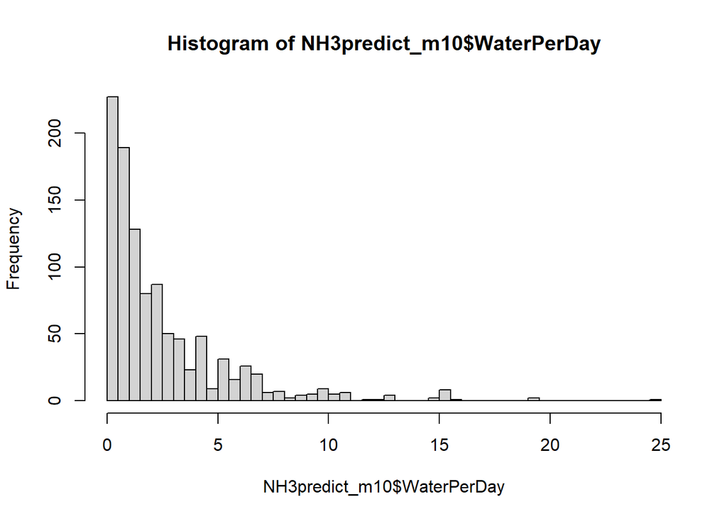

```r
#  Model
m10_lm <- lm(sqrt(NH3loss+4) ~ WaterPerDay + offset(M1_fit),
             weights=Weight,
             data=NH3predict_m10)
```

Heteroscedasticity and normality of erros were as below:

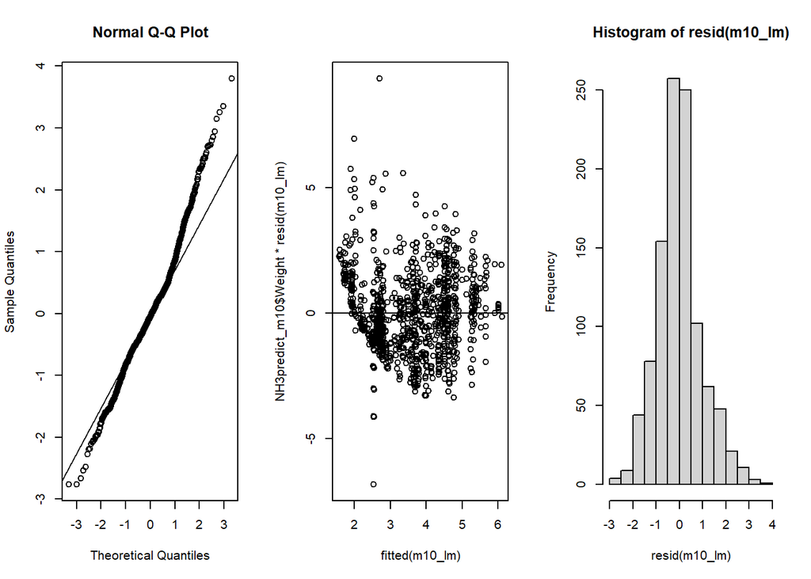

There was no effect of water input on NH3-loss (F(1, 1042) =1.68, p = 0.195).

```
##
## Call:
## lm(formula = sqrt(NH3loss + 4) ~ WaterPerDay + offset(M1_fit),
##     data = NH3predict_m10, weights = Weight)
##
## Weighted Residuals:
##     Min      1Q  Median      3Q     Max
## -4.1648 -0.7772 -0.0771  0.7106  5.9502
##
## Coefficients:
##              Estimate Std. Error t value Pr(>|t|)
## (Intercept)  0.025278   0.034668   0.729    0.466
## WaterPerDay -0.011399   0.008797  -1.296    0.195
##
## Residual standard error: 1.205 on 1042 degrees of freedom
## Multiple R-squared:  0.001609,   Adjusted R-squared:  0.0006507
## F-statistic: 1.679 on 1 and 1042 DF,  p-value: 0.1953
```

```
## Analysis of Variance Table
##
## Response: sqrt(NH3loss + 4)
##               Df  Sum Sq Mean Sq F value Pr(>F)
## WaterPerDay    1    2.44  2.4363  1.6792 0.1953
## Residuals   1042 1511.86  1.4509
```

Figure below shows a linear approximation of the effect of daily water input (mm) on NH3-emissions (linear slope back-transformed from the square-root scale).

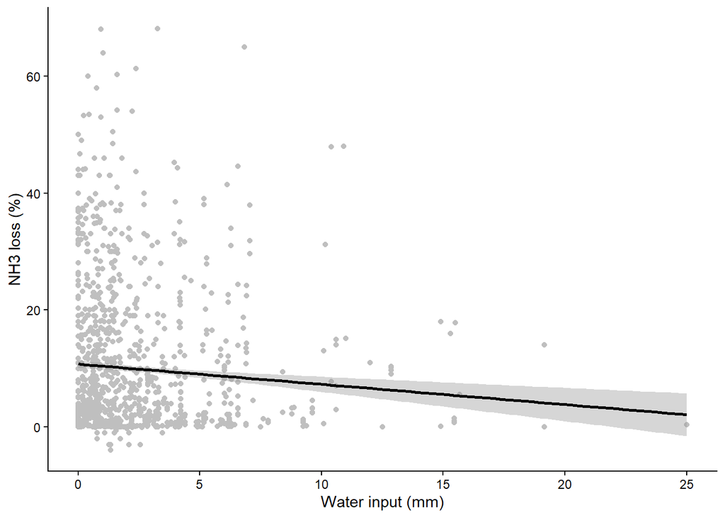

## Model A_Experiment duration

Duration of the experiment (days).

```
##    Min. 1st Qu.  Median    Mean 3rd Qu.    Max.
##    3.00    9.00   15.00   18.49   25.00  120.00
```

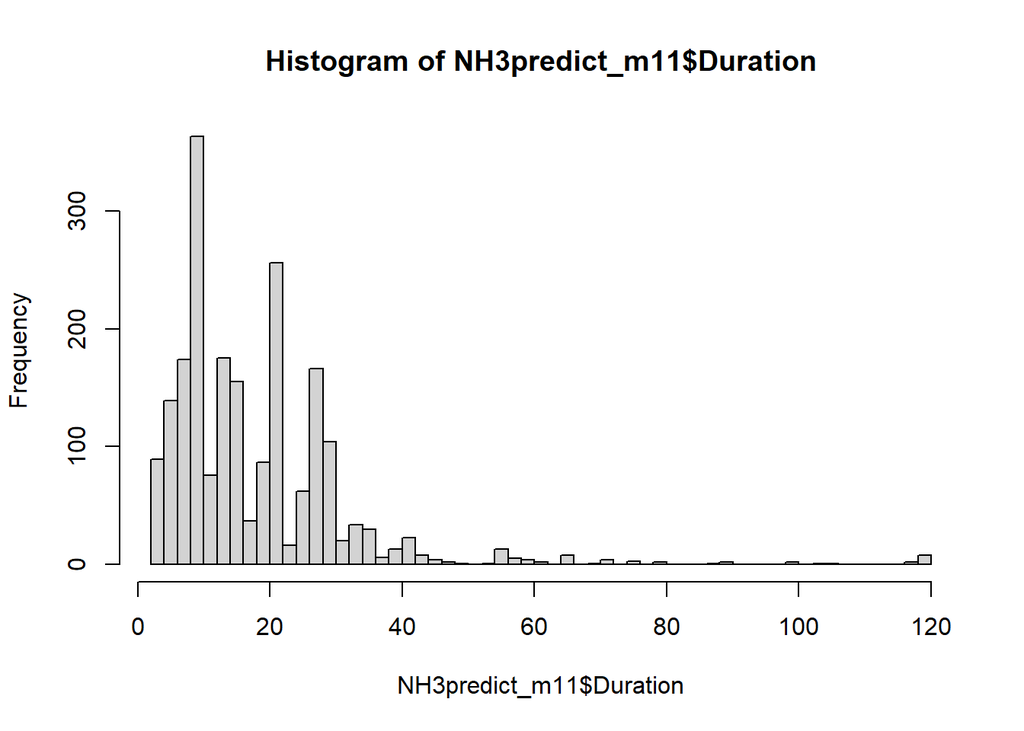

```r
#  Model
m11_lm <- lm(sqrt(NH3loss+4) ~ Duration + offset(M1_fit),
             weights=Weight,
             data=NH3predict_m11)
```

Heteroscedasticity and normality of erros were as below:

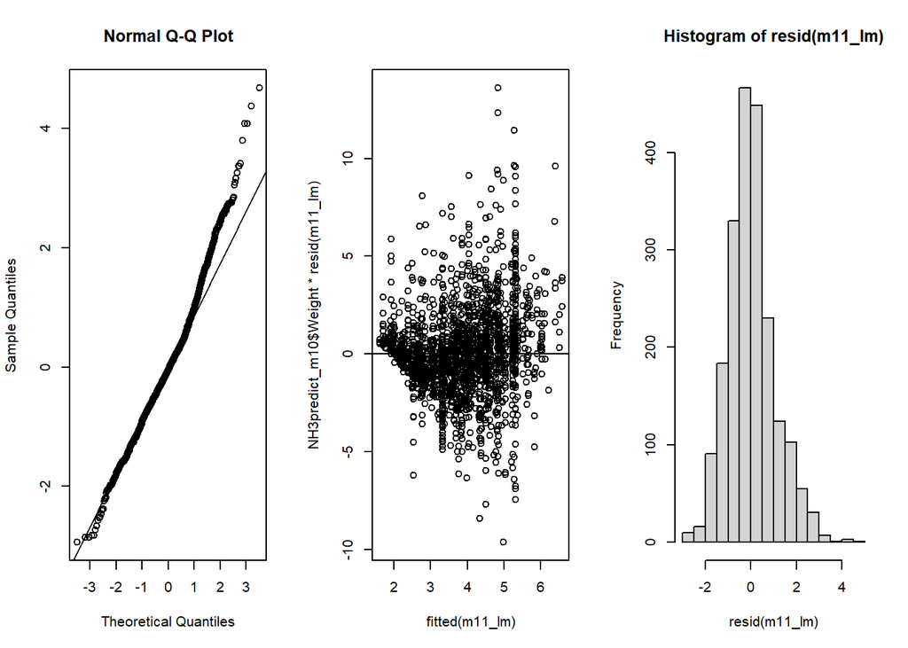

There was no effect of duration of the experiment on NH3-loss (F(1, 2098) =0.16, p = 0.691).

```
##
## Call:
## lm(formula = sqrt(NH3loss + 4) ~ Duration + offset(M1_fit), data = NH3predict_m11,
##     weights = Weight)
##
## Weighted Residuals:
##     Min      1Q  Median      3Q     Max
## -4.1481 -0.8351 -0.0717  0.7290  6.1858
##
## Coefficients:
##               Estimate Std. Error t value Pr(>|t|)
## (Intercept) -0.0124589  0.0346286  -0.360    0.719
## Duration     0.0005908  0.0014872   0.397    0.691
##
## Residual standard error: 1.252 on 2098 degrees of freedom
## Multiple R-squared:  7.522e-05,  Adjusted R-squared:  -0.0004014
## F-statistic: 0.1578 on 1 and 2098 DF,  p-value: 0.6912
```

```
## Analysis of Variance Table
##
## Response: sqrt(NH3loss + 4)
##             Df Sum Sq Mean Sq F value Pr(>F)
## Duration     1    0.2  0.2475  0.1578 0.6912
## Residuals 2098 3290.2  1.5682
```

Adjusted R2-value of the model was -4^{-4}, and multiple R2 was 8^{-5}. The negative adjusted R2-value indicates that the amount of variation accounted for by duration of the experiment is negligible. In practice, it explain no variation in the data.

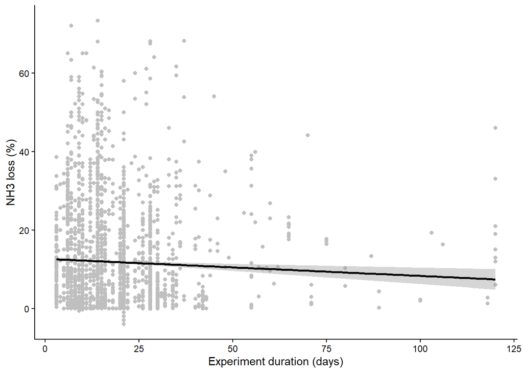

## Combined model with all variables of effect

### Model A1_Base model and pH

```
## Type III Analysis of Variance Table with Satterthwaite's method
##                    Sum Sq Mean Sq NumDF   DenDF  F value    Pr(>F)
## Fertiliser        1210.95  403.65     3 2425.93 242.4259 < 2.2e-16 ***
## Application        193.45   64.48     3 2256.31  38.7281 < 2.2e-16 ***
## Method              53.22    8.87     6  324.71   5.3272 2.928e-05 ***
## Place               63.81   63.81     1  435.61  38.3258 1.384e-09 ***
## pH_cat             131.14  131.14     1 2481.93  78.7621 < 2.2e-16 ***
## Fertiliser:pH_cat  147.75   49.25     3 2406.57  29.5790 < 2.2e-16 ***
## ---
## Signif. codes:  0 '***' 0.001 '**' 0.01 '*' 0.05 '.' 0.1 ' ' 1
```

```
## Linear mixed model fit by REML. t-tests use Satterthwaite's method [
## lmerModLmerTest]
## Formula: sqrt(NH3loss + 4) ~ Fertiliser + Application + Method + Place +
##     pH_cat + Fertiliser:pH_cat + (1 | Ref)
##    Data: NH3predict_mALL5
## Weights: Weight
## Control: lmerControl(optimizer = "bobyqa")
##
## REML criterion at convergence: 7606.4
##
## Scaled residuals:
##     Min      1Q  Median      3Q     Max
## -3.2346 -0.5987 -0.0663  0.5613  4.8177
##
## Random effects:
##  Groups   Name        Variance Std.Dev.
##  Ref      (Intercept) 0.8983   0.9478
##  Residual             1.6650   1.2904
## Number of obs: 2500, groups:  Ref, 246
##
## Fixed effects:
##                                     Estimate Std. Error         df t value
## (Intercept)                          4.68187    0.18060  496.01150  25.924
## FertiliserUAN                       -0.73928    0.19098 2454.37297  -3.871
## Fertiliserammonium+1                -1.56291    0.10223 2460.79490 -15.288
## Fertiliserammonium+2                -2.13270    0.07600 2427.05250 -28.062
## ApplicationIncorporated             -0.90278    0.08711 2401.05339 -10.363
## ApplicationInjected                 -1.02004    0.30157 2477.90326  -3.382
## ApplicationLiquid                   -0.36529    0.11886 1951.93216  -3.073
## Method15N                           -1.67624    0.50579 2056.55598  -3.314
## MethodClosed chamber                -0.88071    0.21998  406.46896  -4.004
## MethodDrager-Tube                   -0.95266    0.38138  187.87343  -2.498
## MethodSemi-open                     -0.04128    0.28352  278.16234  -0.146
## MethodVentilated chambers           -0.55386    0.20769  660.37991  -2.667
## MethodWindtunnel                     0.13623    0.28116  340.89651   0.485
## PlaceLab                             0.90389    0.14601  435.60733   6.191
## pH_catchalky                         0.12816    0.07274 2470.51772   1.762
## FertiliserUAN:pH_catchalky           0.59652    0.24713 2471.04628   2.414
## Fertiliserammonium+1:pH_catchalky    1.24704    0.13759 2402.93923   9.063
## Fertiliserammonium+2:pH_catchalky    0.56907    0.11958 2373.51395   4.759
##                                   Pr(>|t|)
## (Intercept)                        < 2e-16 ***
## FertiliserUAN                     0.000111 ***
## Fertiliserammonium+1               < 2e-16 ***
## Fertiliserammonium+2               < 2e-16 ***
## ApplicationIncorporated            < 2e-16 ***
## ApplicationInjected               0.000730 ***
## ApplicationLiquid                 0.002147 **
## Method15N                         0.000935 ***
## MethodClosed chamber              7.42e-05 ***
## MethodDrager-Tube                 0.013350 *
## MethodSemi-open                   0.884336
## MethodVentilated chambers         0.007848 **
## MethodWindtunnel                  0.628317
## PlaceLab                          1.38e-09 ***
## pH_catchalky                      0.078197 .
## FertiliserUAN:pH_catchalky        0.015859 *
## Fertiliserammonium+1:pH_catchalky  < 2e-16 ***
## Fertiliserammonium+2:pH_catchalky 2.06e-06 ***
## ---
## Signif. codes:  0 '***' 0.001 '**' 0.01 '*' 0.05 '.' 0.1 ' ' 1
```

```
##
## Correlation matrix not shown by default, as p = 18 > 12.
## Use print(x, correlation=TRUE)  or
##     vcov(x)        if you need it
```

Total observations = 2500

Model A1 explains 50.31 % of the variation in the data (conditional R2), with the fixed effects explaining 23.5 % (marginal R2). The R2-values for linear mixed effects model were calculated according to Nagakawa & Schielzeth (2013).

```
##                Factor               Level    Effect        SE        df
## 1          Fertiliser               urea+ 17.919912 1.6946279  707.3647
## 2          Fertiliser                 UAN 11.544046 2.0312257 1817.6292
## 3          Fertiliser          ammonium+1  5.727903 1.2613889 1053.2575
## 4          Fertiliser          ammonium+2  2.498291 0.9780216  905.5284
## 5         Application           Broadcast 17.919912 1.6946279  707.3647
## 6         Application        Incorporated 10.281500 1.4894691  953.3628
## 7         Application            Injected  9.408981 2.5835509 4550.0871
## 8         Application              Liquid 14.632893 1.8001572  969.0485
## 9              Method            Micromet 17.919912 1.6946279  707.3647
## 10             Method                 15N  5.033829 2.8675313 7640.5251
## 11             Method      Closed chamber 10.448826 1.1134197  371.5260
## 12             Method         Drager-Tube  9.907021 2.5479929  197.3989
## 13             Method           Semi-open 17.535051 2.0563131  288.3401
## 14             Method Ventilated chambers 13.040500 1.1705462  512.7824
```

[output cut: 41 more lines]

### Model A2_Base model, pH, and Clay

A knowledge of air temperature means having access to data concerning the date, time and location of fertilizer applications. If these data are not available, a model that omits this variable but includes the clay content of the soil could be advantageous, since the clay content will often be known.

```
## Type III Analysis of Variance Table with Satterthwaite's method
##                    Sum Sq Mean Sq NumDF   DenDF  F value    Pr(>F)
## Fertiliser        1196.41  398.80     3 2224.82 249.3346 < 2.2e-16 ***
## Application        135.73   45.24     3 2117.33  28.2857 < 2.2e-16 ***
## Method              58.99    9.83     6  310.96   6.1472 4.165e-06 ***
## Place               62.04   62.04     1  426.49  38.7852 1.135e-09 ***
## pH_cat             145.96  145.96     1 2275.93  91.2554 < 2.2e-16 ***
## Clay                39.12   39.12     1 2139.91  24.4563 8.193e-07 ***
## Fertiliser:pH_cat  134.20   44.73     3 2209.92  27.9682 < 2.2e-16 ***
## ---
## Signif. codes:  0 '***' 0.001 '**' 0.01 '*' 0.05 '.' 0.1 ' ' 1
```

```
## Linear mixed model fit by REML. t-tests use Satterthwaite's method [
## lmerModLmerTest]
## Formula: sqrt(NH3loss + 4) ~ Fertiliser + Application + Method + Place +
##     pH_cat + Fertiliser:pH_cat + Clay + (1 | Ref)
##    Data: NH3predict_mALL2
## Weights: Weight
## Control: lmerControl(optimizer = "bobyqa")
##
## REML criterion at convergence: 6921.8
##
## Scaled residuals:
##     Min      1Q  Median      3Q     Max
## -3.3029 -0.5959 -0.0610  0.5838  4.7186
##
## Random effects:
##  Groups   Name        Variance Std.Dev.
##  Ref      (Intercept) 0.9755   0.9877
##  Residual             1.5995   1.2647
## Number of obs: 2295, groups:  Ref, 217
##
## Fixed effects:
##                                     Estimate Std. Error         df t value
## (Intercept)                        5.077e+00  2.038e-01  6.011e+02  24.918
## FertiliserUAN                     -8.231e-01  1.980e-01  2.252e+03  -4.157
## Fertiliserammonium+1              -1.514e+00  1.078e-01  2.255e+03 -14.049
## Fertiliserammonium+2              -2.216e+00  7.865e-02  2.214e+03 -28.182
## ApplicationIncorporated           -8.326e-01  9.506e-02  2.173e+03  -8.759
## ApplicationInjected               -9.369e-01  2.991e-01  2.268e+03  -3.132
## ApplicationLiquid                 -3.747e-01  1.200e-01  1.933e+03  -3.121
## Method15N                         -1.910e+00  5.068e-01  1.840e+03  -3.768
## MethodClosed chamber              -1.091e+00  2.364e-01  4.199e+02  -4.614
## MethodDrager-Tube                 -1.251e+00  4.444e-01  1.720e+02  -2.814
## MethodSemi-open                   -1.558e-01  3.218e-01  2.448e+02  -0.484
## MethodVentilated chambers         -7.487e-01  2.195e-01  7.527e+02  -3.410
## MethodWindtunnel                   2.462e-02  3.059e-01  3.379e+02   0.080
## PlaceLab                           9.471e-01  1.521e-01  4.265e+02   6.228
## pH_catchalky                       1.713e-01  7.360e-02  2.272e+03   2.328
## Clay                              -1.158e-02  2.341e-03  2.140e+03  -4.945
## FertiliserUAN:pH_catchalky         6.916e-01  2.491e-01  2.264e+03   2.777
## Fertiliserammonium+1:pH_catchalky  1.210e+00  1.419e-01  2.208e+03   8.528
```

[output cut: 8 more lines]

```
## ApplicationLiquid                 0.001828 **
## Method15N                         0.000170 ***
## MethodClosed chamber              5.25e-06 ***
## MethodDrager-Tube                 0.005461 **
## MethodSemi-open                   0.628681
## MethodVentilated chambers         0.000684 ***
## MethodWindtunnel                  0.935913
## PlaceLab                          1.13e-09 ***
## pH_catchalky                      0.020000 *
## Clay                              8.19e-07 ***
## FertiliserUAN:pH_catchalky        0.005538 **
## Fertiliserammonium+1:pH_catchalky  < 2e-16 ***
## Fertiliserammonium+2:pH_catchalky 3.43e-07 ***
## ---
## Signif. codes:  0 '***' 0.001 '**' 0.01 '*' 0.05 '.' 0.1 ' ' 1
```

```
##
## Correlation matrix not shown by default, as p = 19 > 12.
## Use print(x, correlation=TRUE)  or
##     vcov(x)        if you need it
```

```
##            R2m      R2c
## [1,] 0.2517503 0.535219
```

Model A2 pH explains 53.52 % of the variation in the data (conditional R2), with the fixed effects explaining 25.18 % (marginal R2). Total observations = 2295

### Model A3_Base model, pH and temperature

```
## Type III Analysis of Variance Table with Satterthwaite's method
##                   Sum Sq Mean Sq NumDF   DenDF  F value    Pr(>F)
## Fertiliser        873.76 291.253     3 1756.91 179.4046 < 2.2e-16 ***
## Application       101.13  33.711     3 1511.49  20.7651 3.479e-13 ***
## Method             54.93   9.155     6  254.79   5.6395 1.619e-05 ***
## Place              26.74  26.737     1  238.06  16.4694 6.708e-05 ***
## pH_cat            120.82 120.825     1 1835.92  74.4248 < 2.2e-16 ***
## AirTemperature     44.57  44.573     1 1778.92  27.4556 1.799e-07 ***
## Fertiliser:pH_cat  86.54  28.846     3 1798.49  17.7687 2.291e-11 ***
## ---
## Signif. codes:  0 '***' 0.001 '**' 0.01 '*' 0.05 '.' 0.1 ' ' 1
```

```
## Linear mixed model fit by REML. t-tests use Satterthwaite's method [
## lmerModLmerTest]
## Formula: sqrt(NH3loss + 4) ~ Fertiliser + Application + Method + Place +
##     pH_cat + Fertiliser:pH_cat + AirTemperature + (1 | Ref)
##    Data: NH3predict_mALL4
## Weights: Weight
## Control: lmerControl(optimizer = "bobyqa")
##
## REML criterion at convergence: 5608.9
##
## Scaled residuals:
##     Min      1Q  Median      3Q     Max
## -3.4270 -0.6144 -0.0236  0.5605  4.8889
##
## Random effects:
##  Groups   Name        Variance Std.Dev.
##  Ref      (Intercept) 0.8958   0.9465
##  Residual             1.6234   1.2741
## Number of obs: 1855, groups:  Ref, 180
##
## Fixed effects:
##                                     Estimate Std. Error         df t value
## (Intercept)                        4.350e+00  2.132e-01  4.253e+02  20.404
## FertiliserUAN                     -8.007e-01  2.212e-01  1.739e+03  -3.620
## Fertiliserammonium+1              -1.630e+00  1.338e-01  1.835e+03 -12.182
## Fertiliserammonium+2              -2.053e+00  8.333e-02  1.793e+03 -24.632
## ApplicationIncorporated           -7.974e-01  1.083e-01  1.712e+03  -7.362
## ApplicationInjected               -9.961e-01  3.055e-01  1.833e+03  -3.261
## ApplicationLiquid                 -1.559e-01  1.559e-01  1.152e+03  -1.000
## Method15N                         -1.627e+00  5.497e-01  1.743e+03  -2.961
## MethodClosed chamber              -1.099e+00  2.522e-01  3.146e+02  -4.359
## MethodDrager-Tube                 -1.375e+00  4.085e-01  1.433e+02  -3.365
## MethodSemi-open                   -2.673e-01  3.209e-01  2.149e+02  -0.833
## MethodVentilated chambers         -8.506e-01  2.337e-01  5.237e+02  -3.639
## MethodWindtunnel                   7.028e-03  2.949e-01  2.770e+02   0.024
## PlaceLab                           7.643e-01  1.883e-01  2.381e+02   4.058
## pH_catchalky                       2.137e-01  8.279e-02  1.835e+03   2.581
## AirTemperature                     2.678e-02  5.111e-03  1.779e+03   5.240
## FertiliserUAN:pH_catchalky         6.331e-01  2.714e-01  1.831e+03   2.333
## Fertiliserammonium+1:pH_catchalky  1.240e+00  1.801e-01  1.809e+03   6.886
```

[output cut: 8 more lines]

```
## ApplicationLiquid                 0.317520
## Method15N                         0.003111 **
## MethodClosed chamber              1.77e-05 ***
## MethodDrager-Tube                 0.000983 ***
## MethodSemi-open                   0.405821
## MethodVentilated chambers         0.000301 ***
## MethodWindtunnel                  0.981002
## PlaceLab                          6.71e-05 ***
## pH_catchalky                      0.009935 **
## AirTemperature                    1.80e-07 ***
## FertiliserUAN:pH_catchalky        0.019766 *
## Fertiliserammonium+1:pH_catchalky 7.91e-12 ***
## Fertiliserammonium+2:pH_catchalky 0.000349 ***
## ---
## Signif. codes:  0 '***' 0.001 '**' 0.01 '*' 0.05 '.' 0.1 ' ' 1
```

```
##
## Correlation matrix not shown by default, as p = 19 > 12.
## Use print(x, correlation=TRUE)  or
##     vcov(x)        if you need it
```

```
##            R2m       R2c
## [1,] 0.2459792 0.5140902
```

Total observations = 1855

Model A3 explains 51.41 % of the variation in the data (conditional R2), with the fixed effects explaining 24.6 % (marginal R2). The R2-values for linear mixed effects model were calculated according to Nagakawa & Schielzeth (2013).

### Model Base model, pH and temperature (Lab only)

```
## Type III Analysis of Variance Table with Satterthwaite's method
##                   Sum Sq Mean Sq NumDF  DenDF  F value    Pr(>F)
## Fertiliser        604.42 201.473     3 634.09 115.5698 < 2.2e-16 ***
## Application        72.75  36.377     2 352.57  20.8667 2.724e-09 ***
## Method              2.99   2.988     1  87.25   1.7143  0.193871
## pH_cat             32.29  32.294     1 630.71  18.5248 1.944e-05 ***
## AirTemperature     19.76  19.764     1 779.29  11.3371  0.000797 ***
## Fertiliser:pH_cat  44.43  14.810     3 703.25   8.4951 1.506e-05 ***
## ---
## Signif. codes:  0 '***' 0.001 '**' 0.01 '*' 0.05 '.' 0.1 ' ' 1
```

```
## Linear mixed model fit by REML. t-tests use Satterthwaite's method [
## lmerModLmerTest]
## Formula: sqrt(NH3loss + 4) ~ Fertiliser + Application + Method + pH_cat +
##     Fertiliser:pH_cat + AirTemperature + (1 | Ref)
##    Data: NH3predict_mALL4b
## Weights: Weight
## Control: lmerControl(optimizer = "bobyqa")
##
## REML criterion at convergence: 2580.2
##
## Scaled residuals:
##     Min      1Q  Median      3Q     Max
## -3.0101 -0.5699 -0.0542  0.5866  4.7680
##
## Random effects:
##  Groups   Name        Variance Std.Dev.
##  Ref      (Intercept) 1.144    1.07
##  Residual             1.743    1.32
## Number of obs: 802, groups:  Ref, 65
##
## Fixed effects:
##                                     Estimate Std. Error         df t value
## (Intercept)                         4.271759   0.330019 189.888131  12.944
## FertiliserUAN                      -0.863632   0.605345 644.484445  -1.427
## Fertiliserammonium+1               -1.988054   0.204049 789.695414  -9.743
## Fertiliserammonium+2               -2.822047   0.167080 779.054345 -16.890
## ApplicationIncorporated            -1.412057   0.225934 428.961238  -6.250
## ApplicationLiquid                  -0.633869   0.258249 318.616056  -2.454
## MethodVentilated chambers           0.384527   0.293690  87.245980   1.309
## pH_catchalky                        0.377948   0.117898 777.217195   3.206
## AirTemperature                      0.029339   0.008714 779.290147   3.367
## FertiliserUAN:pH_catchalky          1.108508   0.968297 611.074734   1.145
## Fertiliserammonium+1:pH_catchalky   1.052810   0.248050 771.353159   4.244
## Fertiliserammonium+2:pH_catchalky   0.724059   0.198393 748.153882   3.650
##                                   Pr(>|t|)
## (Intercept)                        < 2e-16 ***
## FertiliserUAN                     0.154157
## Fertiliserammonium+1               < 2e-16 ***
## Fertiliserammonium+2               < 2e-16 ***
## ApplicationIncorporated           9.92e-10 ***
```

[output cut: 20 more lines]

[output not shown]

### Model A4_Base variables, pH, clay, and temperature

```r
mALL_lmer <- lmer(sqrt(NH3loss+4) ~ Fertiliser + Application + Method + Place +
                    pH_cat + Fertiliser:pH_cat +
                    Clay + AirTemperature +
                    (1|Ref),
                   weights=Weight,
                   control=lmerControl(optimizer="bobyqa"),
                   data=NH3predict_mALL)
```

Total observations = 1693

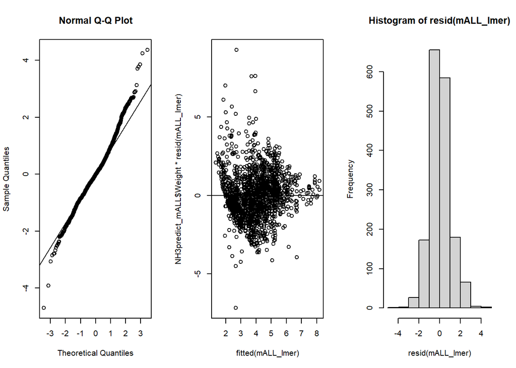

```
## Type III Analysis of Variance Table with Satterthwaite's method
##                   Sum Sq Mean Sq NumDF   DenDF F value    Pr(>F)
## Fertiliser        873.34 291.112     3 1600.41 186.638 < 2.2e-16 ***
## Application        78.54  26.181     3 1406.59  16.785 1.025e-10 ***
## Method             60.76  10.126     6  244.01   6.492 2.273e-06 ***
## Place              21.40  21.396     1  220.22  13.717 0.0002687 ***
## pH_cat            149.61 149.611     1 1672.64  95.919 < 2.2e-16 ***
## Clay               59.25  59.253     1 1563.00  37.988 9.038e-10 ***
## AirTemperature     48.20  48.201     1 1647.72  30.903 3.159e-08 ***
## Fertiliser:pH_cat  91.56  30.522     3 1641.59  19.568 1.825e-12 ***
## ---
## Signif. codes:  0 '***' 0.001 '**' 0.01 '*' 0.05 '.' 0.1 ' ' 1
```

```
## Linear mixed model fit by REML. t-tests use Satterthwaite's method [
## lmerModLmerTest]
## Formula: sqrt(NH3loss + 4) ~ Fertiliser + Application + Method + Place +
##     pH_cat + Fertiliser:pH_cat + Clay + AirTemperature + (1 |      Ref)
##    Data: NH3predict_mALL
## Weights: Weight
## Control: lmerControl(optimizer = "bobyqa")
##
## REML criterion at convergence: 5081.9
##
## Scaled residuals:
##     Min      1Q  Median      3Q     Max
## -3.5115 -0.6062 -0.0181  0.5874  4.7424
##
## Random effects:
##  Groups   Name        Variance Std.Dev.
##  Ref      (Intercept) 0.9558   0.9777
##  Residual             1.5598   1.2489
## Number of obs: 1693, groups:  Ref, 159
##
## Fixed effects:
##                                     Estimate Std. Error         df t value
## (Intercept)                        4.796e+00  2.314e-01  4.726e+02  20.726
## FertiliserUAN                     -9.248e-01  2.335e-01  1.572e+03  -3.961
## Fertiliserammonium+1              -1.669e+00  1.452e-01  1.673e+03 -11.495
## Fertiliserammonium+2              -2.164e+00  8.679e-02  1.625e+03 -24.928
## ApplicationIncorporated           -8.078e-01  1.217e-01  1.454e+03  -6.637
## ApplicationInjected               -8.928e-01  3.044e-01  1.667e+03  -2.933
## ApplicationLiquid                 -1.811e-01  1.597e-01  1.161e+03  -1.134
## Method15N                         -1.809e+00  5.479e-01  1.550e+03  -3.301
## MethodClosed chamber              -1.206e+00  2.656e-01  2.980e+02  -4.541
## MethodDrager-Tube                 -1.633e+00  4.764e-01  1.249e+02  -3.427
## MethodSemi-open                   -1.282e-01  3.499e-01  1.854e+02  -0.366
## MethodVentilated chambers         -1.011e+00  2.419e-01  5.445e+02  -4.180
## MethodWindtunnel                  -6.627e-03  3.156e-01  2.602e+02  -0.021
## PlaceLab                           7.374e-01  1.991e-01  2.202e+02   3.704
## pH_catchalky                       2.850e-01  8.449e-02  1.673e+03   3.373
## Clay                              -1.732e-02  2.811e-03  1.563e+03  -6.163
## AirTemperature                     2.854e-02  5.135e-03  1.648e+03   5.559
## FertiliserUAN:pH_catchalky         7.992e-01  2.751e-01  1.669e+03   2.905
```

[output cut: 10 more lines]

```
## Method15N                         0.000986 ***
## MethodClosed chamber              8.14e-06 ***
## MethodDrager-Tube                 0.000828 ***
## MethodSemi-open                   0.714476
## MethodVentilated chambers         3.39e-05 ***
## MethodWindtunnel                  0.983263
## PlaceLab                          0.000269 ***
## pH_catchalky                      0.000760 ***
## Clay                              9.04e-10 ***
## AirTemperature                    3.16e-08 ***
## FertiliserUAN:pH_catchalky        0.003726 **
## Fertiliserammonium+1:pH_catchalky 4.47e-12 ***
## Fertiliserammonium+2:pH_catchalky 6.54e-05 ***
## ---
## Signif. codes:  0 '***' 0.001 '**' 0.01 '*' 0.05 '.' 0.1 ' ' 1
```

```
##
## Correlation matrix not shown by default, as p = 20 > 12.
## Use print(x, correlation=TRUE)  or
##     vcov(x)        if you need it
```

```
##            R2m       R2c
## [1,] 0.2705194 0.5476962
```

Model A4 explains 54.77 % of the variation in the data (conditional R2), with the fixed effects explaining 27.05 % (marginal R2).

```
##                Factor               Level    Effect       SE        df
## 1          Fertiliser               urea+ 20.790548 2.093380  578.1419
## 2          Fertiliser                 UAN 12.436507 2.480723 1256.8403
## 3          Fertiliser          ammonium+1  6.955899 1.643244  966.3023
## 4          Fertiliser          ammonium+2  3.926909 1.247800  711.6701
## 5         Application           Broadcast 20.790548 2.093380  578.1419
## 6         Application        Incorporated 13.399202 1.993767  823.3704
## 7         Application            Injected 12.697212 3.037676 2859.3665
## 8         Application              Liquid 19.019573 2.451873  787.6866
## 9              Method            Micromet 20.790548 2.093380  578.1419
## 10             Method                 15N  6.052118 3.275337 4327.6732
## 11             Method      Closed chamber 10.233983 1.487889  221.6397
## 12             Method         Drager-Tube  7.198988 2.910562  137.8315
## 13             Method           Semi-open 19.530282 2.752771  188.1988
## 14             Method Ventilated chambers 11.743811 1.446603  317.1321
```

[output cut: 41 more lines]

The same effect sizes (and their 95% confidence interval) are shown below:

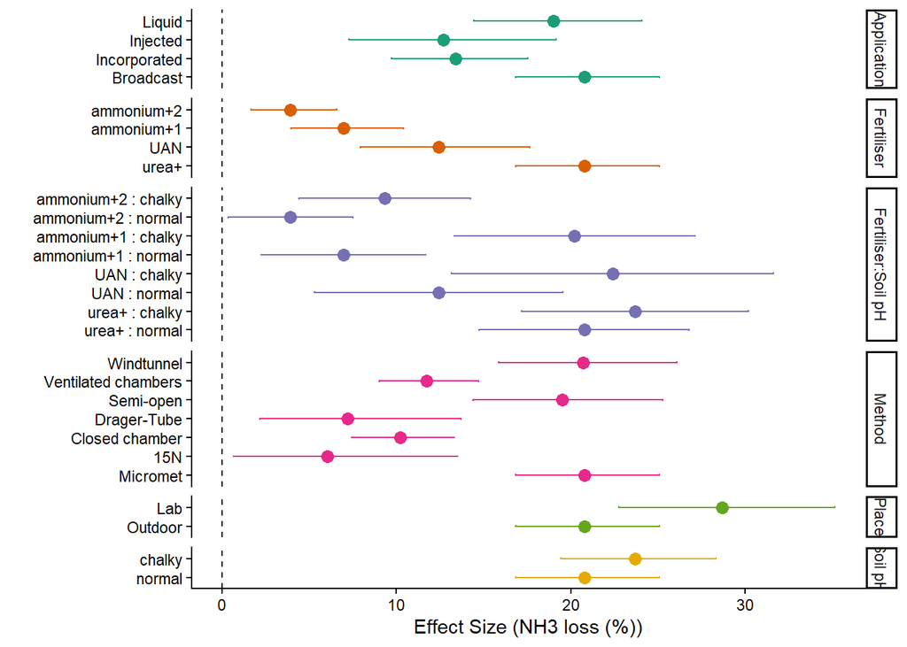

### Model A5

```
## Type III Analysis of Variance Table with Satterthwaite's method
##                           Sum Sq Mean Sq NumDF  DenDF F value    Pr(>F)
## Fertiliser               288.662  96.221     3 899.35 66.0133 < 2.2e-16 ***
## Application               24.444   8.148     3 861.00  5.5899 0.0008467 ***
## Method                    32.874   5.479     6 136.02  3.7589 0.0017106 **
## pH_cat                    27.354  27.354     1 916.91 18.7667 1.640e-05 ***
## AirTemperature            10.661  10.661     1 881.45  7.3138 0.0069745 **
## Rain.mean                  8.102   8.102     1 908.75  5.5587 0.0185998 *
## Fertiliser:pH_cat         37.555  12.518     3 908.59  8.5883 1.261e-05 ***
## AirTemperature:Rain.mean   4.329   4.329     1 911.19  2.9698 0.0851701 .
## ---
## Signif. codes:  0 '***' 0.001 '**' 0.01 '*' 0.05 '.' 0.1 ' ' 1
```

```
## Linear mixed model fit by REML. t-tests use Satterthwaite's method [
## lmerModLmerTest]
## Formula: sqrt(NH3loss + 4) ~ Fertiliser + Application + Method + pH_cat +
##     Fertiliser:pH_cat + AirTemperature + Rain.mean + AirTemperature *
##     Rain.mean + (1 | Ref)
##    Data: NH3predict_mALL3
## Weights: Weight
## Control: lmerControl(optimizer = "bobyqa")
##
## REML criterion at convergence: 2644.7
##
## Scaled residuals:
##     Min      1Q  Median      3Q     Max
## -3.6536 -0.5607 -0.0707  0.5034  4.9803
##
## Random effects:
##  Groups   Name        Variance Std.Dev.
##  Ref      (Intercept) 0.7218   0.8496
##  Residual             1.4576   1.2073
## Number of obs: 941, groups:  Ref, 102
##
## Fixed effects:
##                                     Estimate Std. Error         df t value
## (Intercept)                         4.211611   0.234762 216.464188  17.940
## FertiliserUAN                      -0.997450   0.269392 911.500665  -3.703
## Fertiliserammonium+1               -1.406010   0.213643 911.727212  -6.581
## Fertiliserammonium+2               -1.755481   0.095022 896.647229 -18.475
## ApplicationIncorporated            -0.501969   0.125992 918.660569  -3.984
## ApplicationInjected                -0.324463   0.434981 897.231264  -0.746
## ApplicationLiquid                   0.096800   0.212675 795.776067   0.455
## Method15N                          -0.882317   0.540616 711.140309  -1.632
## MethodClosed chamber               -0.537488   0.281159 101.982462  -1.912
## MethodDrager-Tube                  -0.924700   0.385131  82.574790  -2.401
## MethodSemi-open                    -0.002431   0.319457 118.222012  -0.008
## MethodVentilated chambers          -0.957092   0.280253 212.379889  -3.415
## MethodWindtunnel                    0.148053   0.297705 137.436346   0.497
## pH_catchalky                       -0.050249   0.122719 869.665069  -0.409
## AirTemperature                      0.019556   0.007231 881.453018   2.704
## Rain.mean                          -0.109977   0.046646 908.748832  -2.358
## FertiliserUAN:pH_catchalky          0.832331   0.282931 918.113528   2.942
```

[output cut: 11 more lines]

```
## Method15N                         0.103110
## MethodClosed chamber              0.058723 .
## MethodDrager-Tube                 0.018597 *
## MethodSemi-open                   0.993942
## MethodVentilated chambers         0.000764 ***
## MethodWindtunnel                  0.619764
## pH_catchalky                      0.682302
## AirTemperature                    0.006974 **
## Rain.mean                         0.018600 *
## FertiliserUAN:pH_catchalky        0.003345 **
## Fertiliserammonium+1:pH_catchalky 1.72e-05 ***
## Fertiliserammonium+2:pH_catchalky 0.063712 .
## AirTemperature:Rain.mean          0.085170 .
## ---
## Signif. codes:  0 '***' 0.001 '**' 0.01 '*' 0.05 '.' 0.1 ' ' 1
```

```
##
## Correlation matrix not shown by default, as p = 20 > 12.
## Use print(x, correlation=TRUE)  or
##     vcov(x)        if you need it
```

# GLMM

Results of the final combined model as a GLMM, where no transformation or a constant is necessary. Fitted using glmmTMB (Brooks et al. 2017), with a tweedie probability distribution and a log-link function.

```r
mALL_glmm <- glmmTMB(NH3loss ~ Fertiliser + Application + Method + Place +
                    pH_cat + Fertiliser:pH_cat +
                    Clay + AirTemperature +
                    (1|Ref),
                   dispformula= ~ Fertiliser + Application + Method + Place + pH_cat,
                   family=tweedie(link="log"),
                   data=NH3predict_mALL)
```

```
## Analysis of Deviance Table (Type II Wald chisquare tests)
##
## Response: NH3loss
##                     Chisq Df Pr(>Chisq)
## Fertiliser        632.659  3  < 2.2e-16 ***
## Application        54.738  3  7.808e-12 ***
## Method             46.270  6  2.616e-08 ***
## Place              18.504  1  1.695e-05 ***
## pH_cat             53.183  1  3.039e-13 ***
## Clay               23.960  1  9.836e-07 ***
## AirTemperature     44.580  1  2.442e-11 ***
## Fertiliser:pH_cat  96.296  3  < 2.2e-16 ***
## ---
## Signif. codes:  0 '***' 0.001 '**' 0.01 '*' 0.05 '.' 0.1 ' ' 1
```

```
##  Family: tweedie  ( log )
## Formula:
## NH3loss ~ Fertiliser + Application + Method + Place + pH_cat +
##     Fertiliser:pH_cat + Clay + AirTemperature + (1 | Ref)
## Dispersion:               ~Fertiliser + Application + Method + Place + pH_cat
## Data: NH3predict_mALL
##
##       AIC       BIC    logLik -2*log(L)  df.resid
##   11248.3   11449.4   -5587.2   11174.3      1656
##
## Random effects:
##
## Conditional model:
##  Groups Name        Variance Std.Dev.
##  Ref    (Intercept) 0.569    0.7543
## Number of obs: 1693, groups:  Ref, 159
##
## Conditional model:
##                                    Estimate Std. Error z value Pr(>|z|)
## (Intercept)                        2.883900   0.163165  17.675  < 2e-16 ***
## FertiliserUAN                     -0.582122   0.151607  -3.840 0.000123 ***
## Fertiliserammonium+1              -1.302383   0.114232 -11.401  < 2e-16 ***
## Fertiliserammonium+2              -2.168993   0.092676 -23.404  < 2e-16 ***
## ApplicationIncorporated           -0.738886   0.116139  -6.362 1.99e-10 ***
## ApplicationInjected               -0.969747   0.276429  -3.508 0.000451 ***
## ApplicationLiquid                 -0.297902   0.112316  -2.652 0.007993 **
## Method15N                         -1.050008   0.295572  -3.552 0.000382 ***
## MethodClosed chamber              -1.047186   0.199315  -5.254 1.49e-07 ***
## MethodDrager-Tube                 -1.302679   0.356502  -3.654 0.000258 ***
## MethodSemi-open                   -0.262253   0.252220  -1.040 0.298442
## MethodVentilated chambers         -0.911436   0.176718  -5.158 2.50e-07 ***
## MethodWindtunnel                   0.006630   0.218508   0.030 0.975795
## PlaceLab                           0.667779   0.155239   4.302 1.70e-05 ***
## pH_catchalky                       0.106748   0.054412   1.962 0.049781 *
## Clay                              -0.008509   0.001738  -4.895 9.84e-07 ***
## AirTemperature                     0.026267   0.003934   6.677 2.44e-11 ***
## FertiliserUAN:pH_catchalky         0.670646   0.168303   3.985 6.76e-05 ***
## Fertiliserammonium+1:pH_catchalky  0.863133   0.133188   6.481 9.14e-11 ***
## Fertiliserammonium+2:pH_catchalky  0.997460   0.129457   7.705 1.31e-14 ***
## ---
## Signif. codes:  0 '***' 0.001 '**' 0.01 '*' 0.05 '.' 0.1 ' ' 1
##
## Dispersion model:
##                           Estimate Std. Error z value Pr(>|z|)
## (Intercept)                0.31488    0.13341   2.360  0.01826 *
## FertiliserUAN             -0.28640    0.17645  -1.623  0.10457
## Fertiliserammonium+1       0.04400    0.10450   0.421  0.67371
## Fertiliserammonium+2       0.27073    0.09163   2.955  0.00313 **
## ApplicationIncorporated    0.57271    0.09722   5.891 3.84e-09 ***
## ApplicationInjected        0.03681    0.41148   0.089  0.92871
## ApplicationLiquid         -0.08319    0.10023  -0.830  0.40653
## Method15N                 -2.60434    0.79464  -3.277  0.00105 **
## MethodClosed chamber      -0.19978    0.14422  -1.385  0.16598
## MethodDrager-Tube         -0.12937    0.17553  -0.737  0.46111
## MethodSemi-open           -0.18462    0.18749  -0.985  0.32477
## MethodVentilated chambers -0.02804    0.15032  -0.187  0.85204
## MethodWindtunnel           0.14037    0.15553   0.903  0.36678
## PlaceLab                   0.02495    0.09205   0.271  0.78632
## pH_catchalky              -0.01010    0.07011  -0.144  0.88540
## ---
## Signif. codes:  0 '***' 0.001 '**' 0.01 '*' 0.05 '.' 0.1 ' ' 1
```

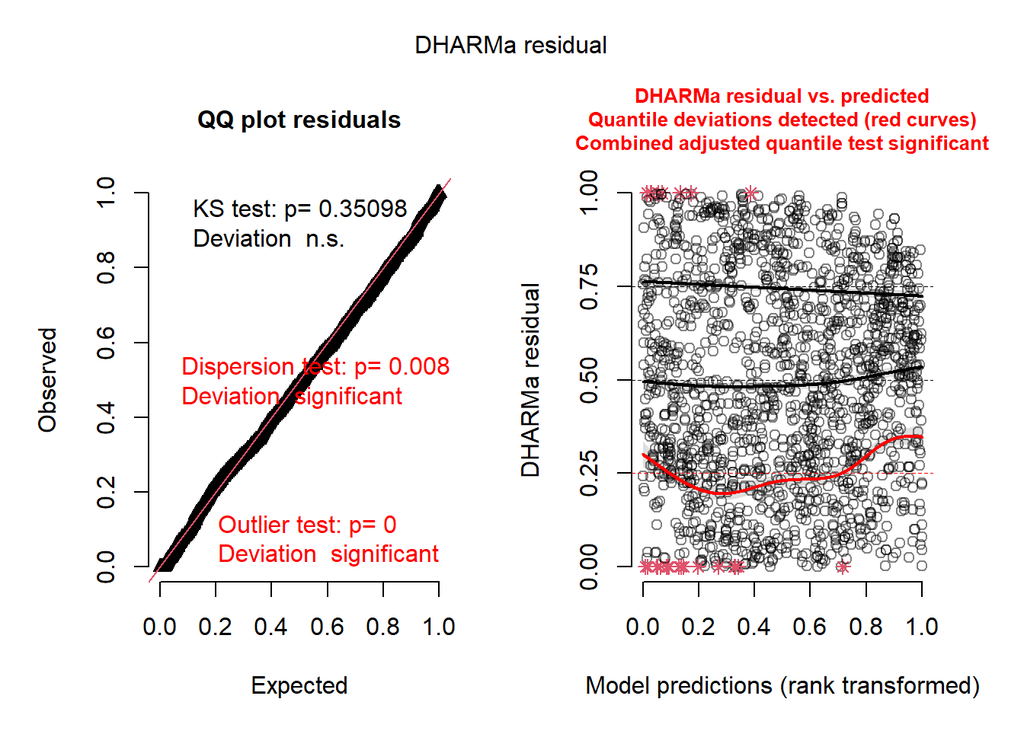

Total observations = 1693

Model GLMM explains 100 % of the variation in the data (conditional R2), with the fixed effects explaining 56.43 % (marginal R2). The R2-values for linear mixed effects model were calculated according to Nagakawa & Schielzeth (2013).

```
##                Factor               Level    Effect        SE  df  lower.CL
## 1          Fertiliser               urea+ 24.721649 3.6001685 Inf 18.583114
## 2          Fertiliser                 UAN 13.812271 2.8494217 Inf  9.218606
## 3          Fertiliser          ammonium+1  6.721398 1.2136075 Inf  4.718106
## 4          Fertiliser          ammonium+2  2.825502 0.4787356 Inf  2.027091
## 5         Application           Broadcast 24.721649 3.6001685 Inf 18.583114
## 6         Application        Incorporated 11.808186 2.1622153 Inf  8.247425
## 7         Application            Injected  9.373928 2.9157737 Inf  5.095117
## 8         Application              Liquid 18.352704 3.2694755 Inf 12.943783
## 9              Method            Micromet 24.721649 3.6001685 Inf 18.583114
## 10             Method                 15N  8.650966 2.3079816 Inf  5.128300
## 11             Method      Closed chamber  8.675414 1.3410323 Inf  6.407857
## 12             Method         Drager-Tube  6.719408 2.2112607 Inf  3.525435
## 13             Method           Semi-open 19.018764 3.9302667 Inf 12.684686
## 14             Method Ventilated chambers  9.936785 1.4160591 Inf  7.515259
```

[output cut: 41 more lines]

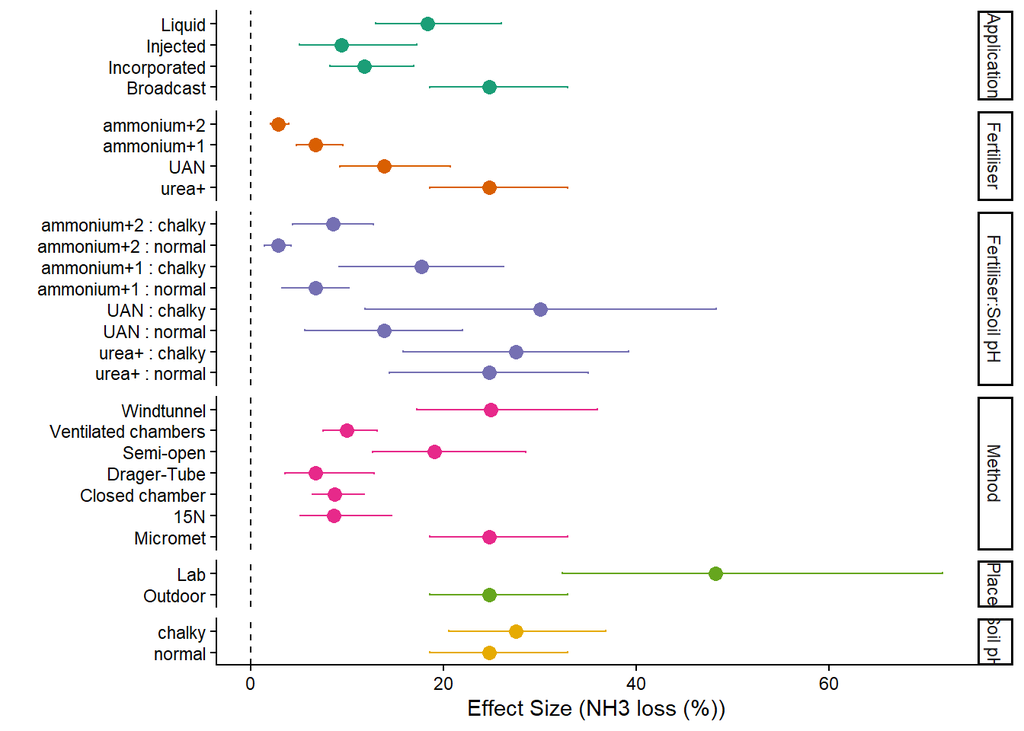

# References

Astivia, Oscar L. Olvera and Zumbo, Bruno D. (2019) “Heteroskedasticity in Multiple Regression Analysis: What it is, How to Detect it and How to Solve it with Applications in R and SPSS,” Practical Assessment, Research, and Evaluation: Vol. 24 , Article 1. DOI: https://doi.org/10.7275/q5xr-fr95

Douglas Bates, Martin Maechler, Ben Bolker, Steve Walker (2015). Fitting Linear Mixed-Effects Models Using lme4. Journal of Statistical Software, 67(1), 1-48. https://doi:10.18637/jss.v067.i01

Mollie E. Brooks, Kasper Kristensen, Koen J. van Benthem, Arni Magnusson, Casper W. Berg, Anders Nielsen, Hans J. Skaug, Martin Maechler and Benjamin M. Bolker (2017). glmmTMB Balances Speed and Flexibility Among Packages for Zero-inflated Generalized Linear Mixed Modeling. The R Journal, 9(2), 378-400. doi: 10.32614/RJ-2017-066.

Nakagawa, S, Schielzeth, H. (2013). A general and simple method for obtaining R^2 from Generalized Linear Mixed-effects Models. Methods in Ecology and Evolution 4: 133-142. https://doi.org/10.1111/j.2041-210x.2012.00261.x